# Proje Rapor :Mehmet Emin Tok 210401072

2024-01-18

# Q1 : Problem Tanımı

Şirketimiz veri analizi şirketidir ve olimpiyat oyunlarında başarısız olan ülkelere geçmis verileri kullanarak raporlar sunmaktadır.Ülkemiz yeterince başarılı değil ve gelecek yıllar için yapacağı yatırımlar için bizim raporlarımıza ihtiyaçları var.

# Q2 : Proje Amacı

[Summer Olympics Medals (1976-2008)](https://www.kaggle.com/datasets/divyansh22/summer-olympics-medals?resource=download) adlı Kaggle veri setini kullanarak analiz edilecek ve ülke olimpiyat komitesine sunulacak raporda istenen kriterler şunlardır:

1)Kadınlarda hentbolda en başarılı 5 ülke hangisi?

2)Yüzmede en başarılı olan ülke hangisi?

3)Meksika’nın en fazla madalya aldığı spor dalı hangisi?

4)Takım sporlarında en başarılı ülke hangisi?

İşe başvuran kişiden bu verilere göre olimpiyat komitemize bir rapor sunmasını ve gelecek yıllarda başarılı olduğuna inandığımız ülkelerden eğitmenler getirilerek bu spor dallarında geleceğimizin inşa edilmesine katkı sağlamasıdır.

# Q3 : Veri Seti Keşifsel Analizi

Veri seti Kaggle web sitesinden indirilmiştir ve **readr::read_csv()** fonksiyonu kullanılarak **olympic** değişkenine ithal edilmiştir.

Veri boyutları aşağıdaki gibidir :

- Satir sayisi : 15433
- Sütun sayisi : 11

Veri setinin bir kısmı aşağıda gösterilmistir:

Aşağıdaki tablo veri setindeki ilk 5 satırı vermektedir:

| City | Year | Sport | Discipline | Event | Athlete | Gender | Country_Code | Country | Event_gender | Medal |
| --- | --- | --- | --- | --- | --- | --- | --- | --- | --- | --- |
| Montreal | 1976 | Aquatics | Diving | 3m springboard | KOHLER, Christa | Women | GDR | East Germany | W | Silver |
| Montreal | 1976 | Aquatics | Diving | 3m springboard | KOSENKOV, Aleksandr | Men | URS | Soviet Union | M | Bronze |
| Montreal | 1976 | Aquatics | Diving | 3m springboard | BOGGS, Philip George | Men | USA | United States | M | Gold |
| Montreal | 1976 | Aquatics | Diving | 3m springboard | CAGNOTTO, Giorgio Franco | Men | ITA | Italy | M | Silver |
| Montreal | 1976 | Aquatics | Diving | 10m platform | WILSON, Deborah Keplar | Women | USA | United States | W | Bronze |

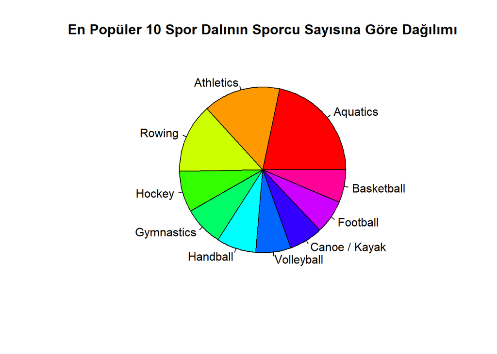

**Yukarıdaki pasta grafiği en fazla sporcu bulunan spor dallarının ilk 10 tanesini gösteriyor.**

# Q4 : Veri Seti Ön İşlemesi

```
##   unique_values_Athlete unique_values_Event
## 1                 11338                 294
```

Atlet sütunu **character** tipinden **factor** tipine dönüştürülmüştür. Ve yukarıdaki raporda athlete ve event sütunlarının unique değer sayıları gösterilmiştir.

# Q5 : Veri mühendisliği

En Başarılı Ülkeler

| Country | Medal |
| --- | --- |
| Korea, South | 83 |
| Norway | 58 |
| Denmark | 46 |
| Hungary | 45 |
| Soviet Union | 43 |

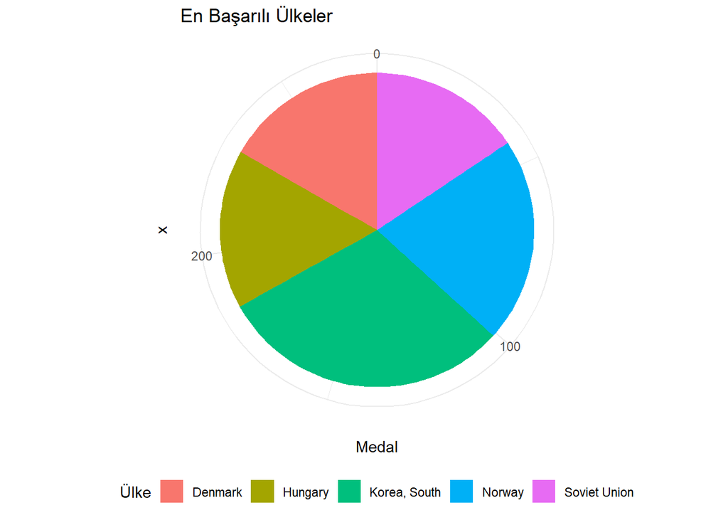

**Kadınlar hentbolda en başarılı ülkelerin listesi**

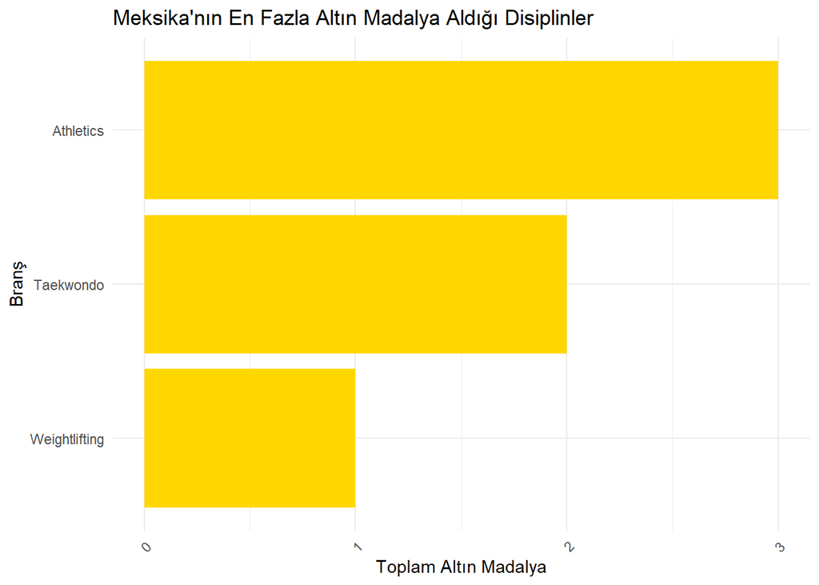

**Ülkemize en yakın şartlara sahip Meksika’nın en başarılı olduğu spor dalları**

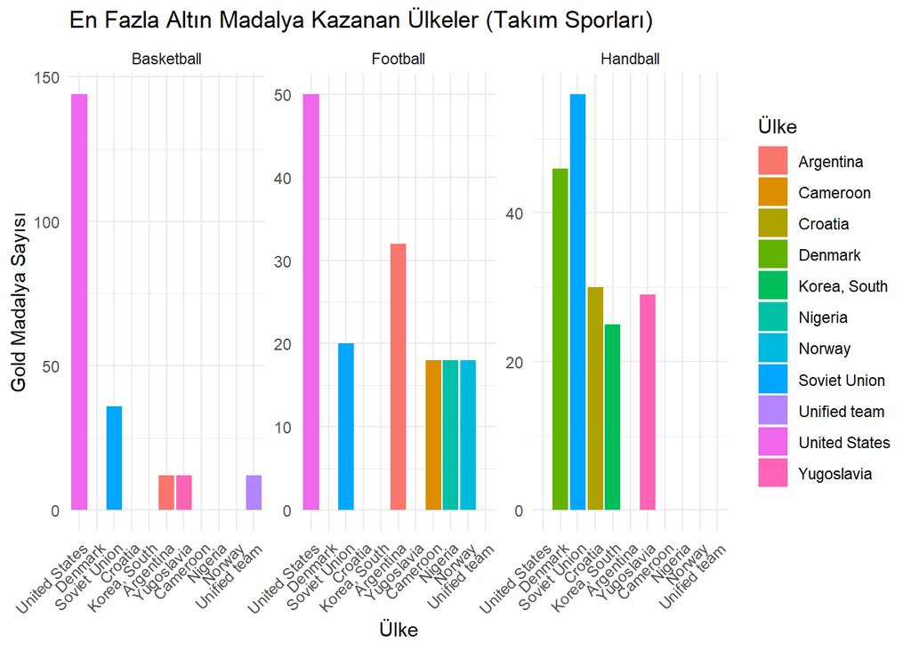

**Yukarıdaki grafikte gruplanmış takım sporlarındaki en başarılı ülkeler listelenmiştir**

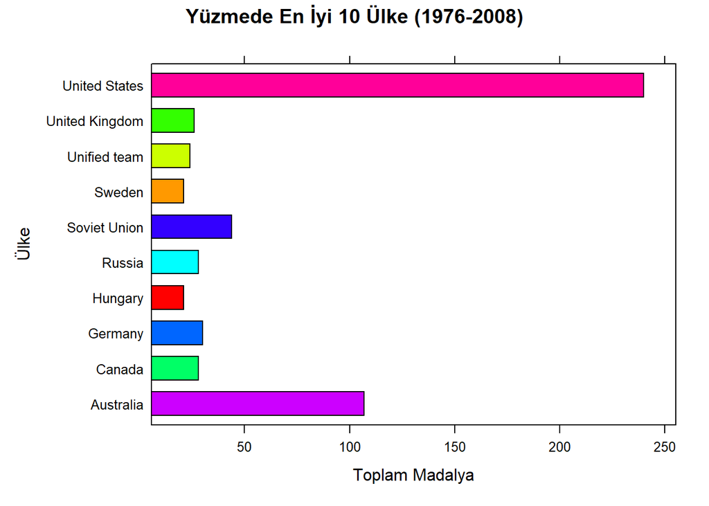

**Erkekler yüzmede en fazla madalya alan ülkelerin listesi**

# Q6 : Veri analizi

[figure not shown]

**Ülkemize en yakın şartlara sahip Meksika’nın en başarılı olduğu spor dalları**

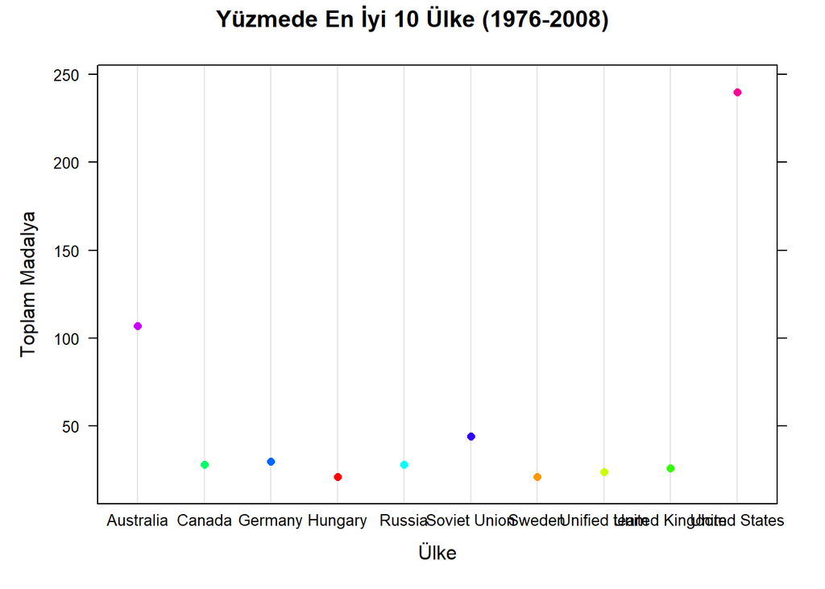

**Ülkemizin kendi içinde başarılı olduğu yüzme alanında globalde başarılı olan ülkelerin grafiği**

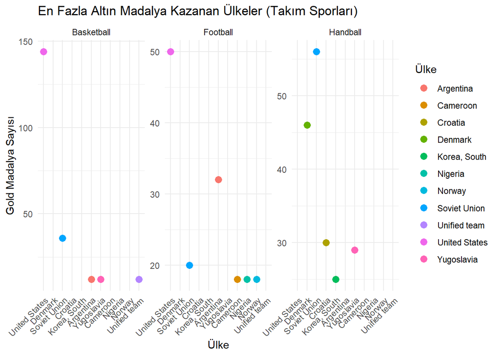

**Takım Sporlarında Örnek Alınabilecek Ülkeler İçin Grafiğimiz**

# Q7 : Sonuç değerlendirme, tavsiyeler

Hayali ülkemiz, olimpiyatlarda başarı sağlayarak spor yatırımlarını hangi ülkelere yönlendirmesi gerektiği konusunda analiz şirketimize başvurdu. 1976-2008 verilerini inceleyerek spor yatırımları konusunda vereceğimiz tavsiyeler şunlardır:

*3)*Ülkemizin Atlas Okyanusu’na kıyısı bulunuyor ve olimpiyat komitesi tarafından yüzme dalında büyük potansiyele sahip olduğumuz belirtilmişti. Son 32 yılın verilerini incelediğimizde, yüzme konusunda ülkemize getirilecek antrenörlerin Amerika Birleşik Devletleri ve Avustralya’dan seçilmesinin uygun olacağını düşündük.

Bu önerilerimiz, ülkemizin spor yatırımlarını daha etkili ve stratejik bir şekilde yönlendirmesine yardımcı olabilir ve maddi olarak zarar etmeden gelecek yatırımlarını yaparak yıllardır özlediği başarılara ulaşmasını sağlayabilir.